# Assignment 1

Emily Hedlund & Tyler Simko

2/12/2018

## Question 1

**Write a paragraph describing the experiment design, including the intervention being tested, the outcome measures being used, how long the study was conducted, and how many poems were included.**

This experiment is a typical randomized field experiment that aims to discover how to maximize online engagement with poetry. Specifically, the experiment tests whether posting a poem with “a colored background increase[s] Facebook interactions on average” (SOC412 slides) in order to best make use of Ruth Lilly’s donation. The design is simple: over the course of 90 days, each poem posted on the Foudation’s Facebook page is randomly assigned a plain or colored background. The outcome measure is the number of “likes, shares, and comments that each poem receives over a 24 hour period of time” (SOC412, assignment 1 write-up). This means that a total of 90 poems were posted, all of similar length and at the same time each day.

## Question 2

**Write a paragraph summarizing the findings. It should describe the range of the dependent variable, the means for each condition, and a statement of the effect size.**

Let’s analyze the data:

```r
summary(poems$interactions) ## find range of d.v.
```

```
##    Min. 1st Qu.  Median    Mean 3rd Qu.    Max.
##    0.00    4.00    9.50   16.79   21.00  111.00
```

```r
tapply(poems$interactions, poems$condition, mean) ## means of each condition
```

```
##     Text    Color
## 12.40000 21.17778
```

```r
lm(interactions ~ condition, data = poems) ## effect size
```

```
##
## Call:
## lm(formula = interactions ~ condition, data = poems)
##
## Coefficients:
##    (Intercept)  conditionColor
##         12.400           8.778
```

```r
summary(lm(interactions ~ condition, data = poems))
```

```
##
## Call:
## lm(formula = interactions ~ condition, data = poems)
##
## Residuals:
##    Min     1Q Median     3Q    Max
## -19.18 -11.34  -7.40   3.85  98.60
##
## Coefficients:
##                Estimate Std. Error t value Pr(>|t|)
## (Intercept)      12.400      2.978   4.164 7.29e-05 ***
## conditionColor    8.778      4.212   2.084   0.0401 *
## ---
## Signif. codes:  0 '***' 0.001 '**' 0.01 '*' 0.05 '.' 0.1 ' ' 1
##
## Residual standard error: 19.98 on 88 degrees of freedom
## Multiple R-squared:  0.04703,    Adjusted R-squared:  0.0362
## F-statistic: 4.343 on 1 and 88 DF,  p-value: 0.04006
```

We can see that the range of interactions is rather large. The minimum number of interactions that a single poem received is 0, while the maximum is 111. This maximum seems to be an outlier, since the mean (16.79) and median (9.5) were much lower. We can find the means for each condition by subsetting and taking means separately: the average number of interactions for a text post is 12.4 (same as the intercept), while the average number for color posts is 21.18 (intercept + $\beta_{interactions}$). This means that the average treatment effect is $21.18 - 12.4 = 8.78$, an increase of 8.78 interactions on average for adding a color background. This effect is significant at an $\alpha = 0.05$ threshold - we see a p-value of $0.0401$.

However, as discussed in class, linear regression relies on the assumption of error normality. Let’s do some simple exploratory data analysis to see if this holds:

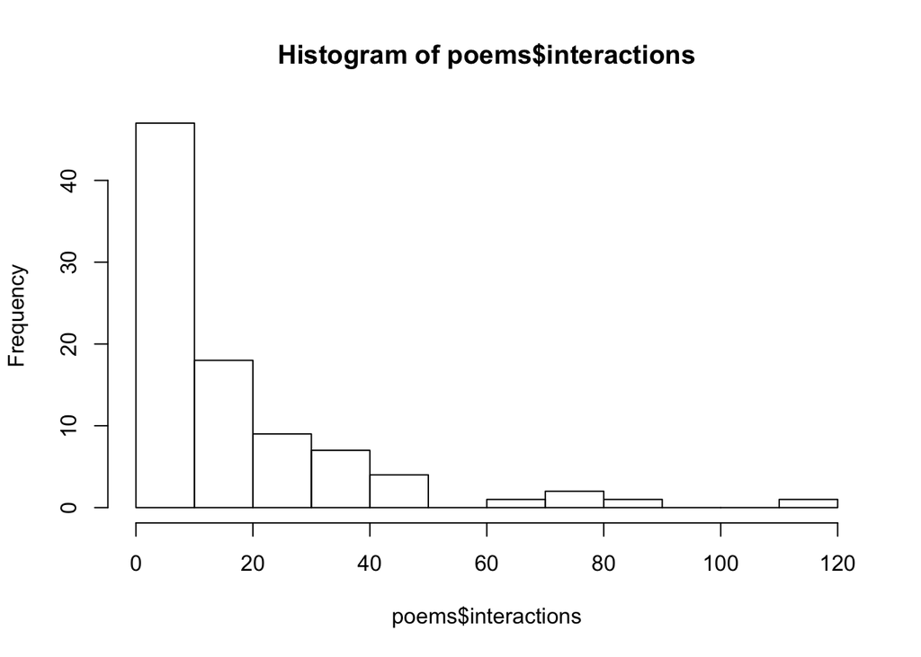

```r
hist(poems$interactions)
```

Doesn’t look very normal to us! We can try to mitigate this by taking the log of the dependent variable and replicating our analysis:

```r
summary(lm(log1p(interactions) ~ condition, data = poems))
```

```
##
## Call:
## lm(formula = log1p(interactions) ~ condition, data = poems)
##
## Residuals:
##      Min       1Q   Median       3Q      Max
## -1.88123 -0.69806 -0.08947  0.71757  2.83727
##
## Coefficients:
##                Estimate Std. Error t value Pr(>|t|)
## (Intercept)      1.8812     0.1483  12.685  < 2e-16 ***
## conditionColor   0.8963     0.2097   4.274 4.86e-05 ***
## ---
## Signif. codes:  0 '***' 0.001 '**' 0.01 '*' 0.05 '.' 0.1 ' ' 1
##
## Residual standard error: 0.9948 on 88 degrees of freedom
## Multiple R-squared:  0.1719, Adjusted R-squared:  0.1625
## F-statistic: 18.26 on 1 and 88 DF,  p-value: 4.858e-05
```

Our results support our initial analysis - it certainly seems like there is a positive effect on interactions from including a colored background (in fact, our p-value shrunk). Since we took the log of our dependent variable, in order to determine our effect size we’ll need to ‘undo’ the log by exponentiating our coefficient: $e^{0.8963} = 2.45$. This means that a colored background leads to over 2 times more (as in, a multiplicative increase in rate) interactions than a text background.

## Question 3

**Write a paragraph that suggests a course of action, contextualizing the findings in a way that the organization would normally think about, such as the outcome per month of choosing the course of action you suggest. For example: “If the Poetry Foundation’s social media account were to always use backgrounds….” Make sure to reflect on the limitations of the sample, which is drawn from the foundation’s page on a single social media platform.**

Through this analysis, we can see that colored backgrounds on poems tend to increase interactions and engagement on the Foundation’s Facebook feed. There are certainly some lessons to be learned here: we saw that adding a colored background, as opposed to just posting a text poem, increased the number of likes, shares, and comments by about 8. As the prompt suggests, we can put this in monthly terms: “if the Poetry Foundation’s Facebook account were to always use colored backgrounds,” this experiment suggests that they would receive approximately $(8.5 * 30) \sim 250$ more Facebook interactions (assuming a 30-day month) per month. This even understates the effect that we saw, since our effect was slightly larger than 8. We say this since it’s often easier to use round numbers when explaining intervention effects to a non-technical audience.

However, we must not extrapolate too much from this sample. While it would certainly be intuitive, notice that we have **not** learned that this works on all social media platforms. For example, we have no solid evidence that adding color backgrounds would increase interactions on, for example, Twitter or Instagram. Given the similar “news feed” nature of these sites it might be intuitive to think so, but if the Poetry Foundation were to consider making this a cross-platform engagement strategy we would advise that another experiment be carried out. In further experiments, we could also test extensions of this claim - perhaps *different* colors have different effects. For example, one might assume that more muted colors could be less effective than brighter colors, for example. Also, this says nothing about how to **grow** your audience, only how to increase interactions among those already following your posts on Facebook.

However, when deciding how to post poems on Facebook in the future, adding a colored background certainly seems like a safe bet to get more online interactions.

## Question 4

**Include a table of results and an illustration of the average treatment effect. You could (a) show the effect with error bars or (b) show fitted(predicted) values for each condition, with error bars for the treatment (color). If you show fitted values, document details of any covariates(predictors) used to generate the fitted values (such as weekend).**

```r
stats <- summarySE(poems, measurevar="interactions", groupvars="condition")
print(stats)
```

```
##   condition  N interactions       sd       se       ci
## 1      Text 45     12.40000 21.67990 3.231849 6.513364
## 2     Color 45     21.17778 18.11866 2.700970 5.443448
```

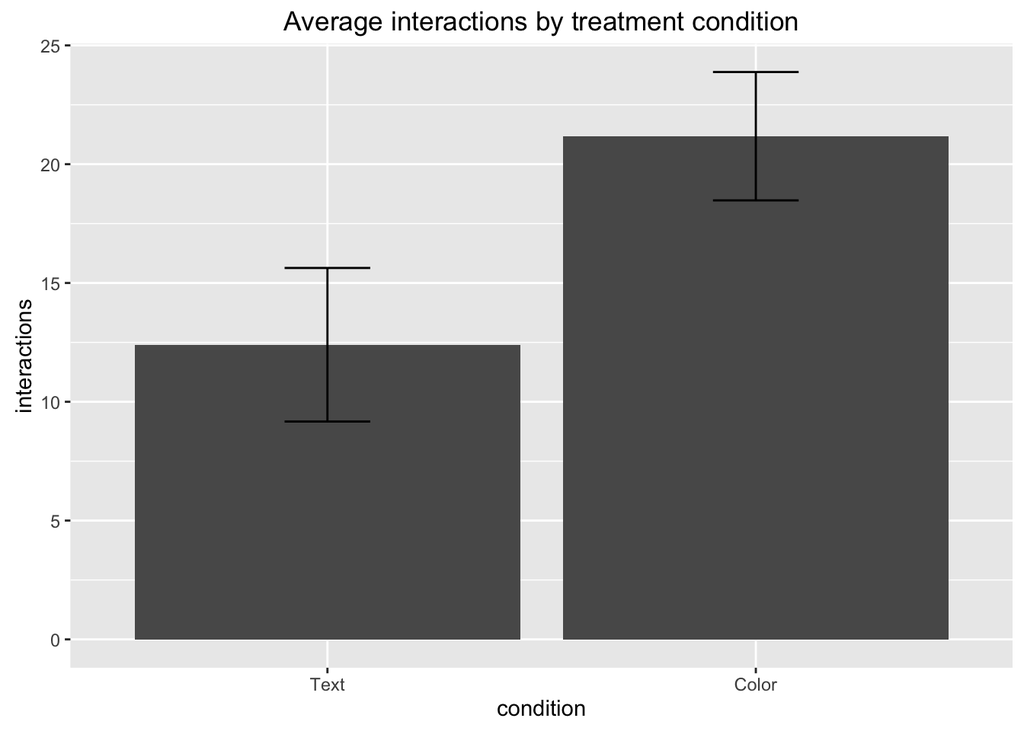

```r
ggplot(stats, aes(x=condition, y=interactions)) +
  geom_bar(position=position_dodge(), stat="identity") +
  geom_errorbar(aes(ymin=interactions-se, ymax=interactions+se),
                width=0.2, position=position_dodge(0.9)) + ggtitle("Average interactions by treatment condition")
```

## Question 5

**Write a paragraph that builds on this finding in the attempt to convince the foundation to do more evaluation, with social media, and more broadly in the organization.**

Clearly, posting poems with eye-catching colors has the potential to significantly increase engagement on social media. The initial evaluation, based entirely on data gathered from the Foundation’s Facebook page, demonstrates promising results. In order to come to a more robust conclusion, more experimentation should be done by the Foundation in the future. These experiments could involve using other social media sites such as Twitter and Instagram, testing the efficacy of specific colors, and matching the color to the mood of the poem or the time of day posted. By tweaking small details from experiment to experiment, the Foundation can determine the optimal combination to maximize engagement and ensure that each poem reaches as many people as possible.